# predicting high growth (1)

## Behnam Zoghi Roudsari and Omar Mohamed

Assignemt 3

Please download data from the CSV file in this OSF link:

https://osf.io/hbza3

First the necessary libraries and packages are imported

```python
import os
import sys
import warnings

import matplotlib.pyplot as plt
import numpy as np
import pandas as pd
import patsy
import sklearn.metrics as metrics
import statsmodels.formula.api as smf
from plotnine import *
from sklearn.ensemble import RandomForestClassifier
from sklearn.linear_model import (
    LinearRegression,
    LogisticRegression,
    LogisticRegressionCV,
)
from sklearn.metrics import (
    auc,
    brier_score_loss,
    confusion_matrix,
    mean_squared_error,
    roc_auc_score,
    roc_curve,
)
from sklearn.model_selection import GridSearchCV, KFold, train_test_split
from sklearn.preprocessing import StandardScaler
from statsmodels.tools.eval_measures import rmse

warnings.filterwarnings("ignore")
```

## Import data

```python
data = pd.read_csv("bisnode_firms_clean.csv")
```

Due to very long processing time, we had to use a smaller sub-sample of the data

```python
data = data.sample(frac=0.2, random_state=42)
```

see the description of the data

```python
data.describe()
```

|  | year | comp_id | amort | curr_assets | curr_liab | extra_exp | extra_inc | extra_profit_loss | fixed_assets | inc_bef_tax | ... | labor_avg_mod | flag_miss_labor_avg | sales_mil_log_sq | prev_sales | sales_growth | high_growth | flag_low_d1_sales_mil_log | flag_high_d1_sales_mil_log | d1_sales_mil_log_mod | d1_sales_mil_log_mod_sq |
| --- | --- | --- | --- | --- | --- | --- | --- | --- | --- | --- | --- | --- | --- | --- | --- | --- | --- | --- | --- | --- | --- |
| count | 27024.000000 | 2.702400e+04 | 2.702400e+04 | 2.702400e+04 | 2.702400e+04 | 2.702300e+04 | 2.702300e+04 | 2.702200e+04 | 2.702400e+04 | 2.702400e+04 | ... | 27024.000000 | 27024.000000 | 27024.000000 | 2.129100e+04 | 1.946600e+04 | 27024.000000 | 27024.000000 | 27024.000000 | 27024.000000 | 27024.000000 |
| mean | 2012.577191 | 1.537893e+11 | 2.133323e+04 | 2.170842e+05 | 1.669212e+05 | 1.191090e+03 | 3.032275e+03 | 1.842643e+03 | 2.767263e+05 | 1.880062e+04 | ... | 1.004376 | 0.272684 | 12.077243 | 4.867198e+05 | inf | 0.064128 | 0.038928 | 0.038225 | 0.011698 | 0.286629 |
| std | 1.682655 | 1.383834e+11 | 3.266517e+05 | 2.097948e+06 | 1.711564e+06 | 3.792214e+04 | 6.385296e+04 | 5.745317e+04 | 5.350228e+06 | 4.884209e+05 | ... | 4.156221 | 0.445348 | 14.850932 | 3.577609e+06 | NaN | 0.244986 | 0.193428 | 0.191743 | 0.535260 | 0.643584 |
| min | 2010.000000 | 1.001034e+06 | -5.780000e+04 | 0.000000e+00 | -7.837037e+03 | -3.035185e+04 | -8.488889e+03 | -1.729541e+06 | 0.000000e+00 | -2.320988e+07 | ... | 0.000000 | 0.000000 | 0.000000 | 0.000000e+00 | -1.000000e+02 | 0.000000 | 0.000000 | 0.000000 | -1.500000 | 0.000000 |
| 25% | 2011.000000 | 2.861729e+10 | 1.481481e+01 | 2.385185e+03 | 2.300000e+03 | 0.000000e+00 | 0.000000e+00 | 0.000000e+00 | 0.000000e+00 | -4.162963e+03 | ... | 0.166667 | 0.000000 | 1.791855 | 6.781481e+03 | -1.949773e+01 | 0.000000 | 0.000000 | 0.000000 | -0.045194 | 0.000000 |
| 50% | 2013.000000 | 1.142927e+11 | 6.777778e+02 | 9.909259e+03 | 1.214074e+04 | 0.000000e+00 | 0.000000e+00 | 0.000000e+00 | 3.709259e+03 | 5.555556e+01 | ... | 0.458333 | 0.000000 | 7.964193 | 3.325185e+04 | 5.083080e+00 | 0.000000 | 0.000000 | 0.000000 | 0.000000 | 0.007258 |
| 75% | 2014.000000 | 2.585798e+11 | 3.582407e+03 | 3.697778e+04 | 4.510185e+04 | 0.000000e+00 | 0.000000e+00 | 0.000000e+00 | 3.777593e+04 | 3.808333e+03 | ... | 0.969446 | 1.000000 | 16.369079 | 1.222333e+05 | 4.102593e+01 | 0.000000 | 0.000000 | 0.000000 | 0.118723 | 0.128966 |
| max | 2015.000000 | 4.641209e+11 | 2.799496e+07 | 1.411015e+08 | 1.376625e+08 | 4.017652e+06 | 5.824415e+06 | 5.824415e+06 | 6.863519e+08 | 4.426366e+07 | ... | 147.621216 | 1.000000 | 190.868332 | 1.110294e+08 | inf | 1.000000 | 1.000000 | 1.000000 | 1.500000 | 2.250000 |

8 rows × 111 columns

The following functions are used from the codes related to CH17 of the book

## Define helper functions

```python
def regression_results(y_true, y_pred):

    # Regression metrics
    explained_variance = metrics.explained_variance_score(y_true, y_pred)
    mean_absolute_error = metrics.mean_absolute_error(y_true, y_pred)
    mse = metrics.mean_squared_error(y_true, y_pred)
    median_absolute_error = metrics.median_absolute_error(y_true, y_pred)
    r2 = metrics.r2_score(y_true, y_pred)

    print("explained_variance: ", round(explained_variance, 4))
    print("r2: ", round(r2, 4))
    print("MAE: ", round(mean_absolute_error, 4))
    print("MSE: ", round(mse, 4))
    print("RMSE: ", round(np.sqrt(mse), 4))


def coef_matrix(X, model):

    coef_matrix = pd.concat(
        [pd.DataFrame(X.columns), pd.DataFrame(np.transpose(model.coef_))], axis=1
    )
    coef_matrix.columns = ["variable", "coefficient"]
    coef_matrix = coef_matrix.append(
        {"variable": "Intercept", "coefficient": model.intercept_},
        ignore_index=True,
    )
    return coef_matrix


def cv_summary(lambdas, C_values, model):
    d = {
        "lambdas": lambdas,
        "C_values": C_values,
        "mean_cv_score": model.scores_[1].mean(axis=0),
    }
    return pd.DataFrame(data=d)


def create_roc_plot(y_true, y_pred):
    fpr, tpr, thresholds = roc_curve(y_true, y_pred)
    all_coords = pd.DataFrame({"fpr": fpr, "tpr": tpr, "thresholds": thresholds})
    color = ["blue", "red", "green"]
    plot = (
        ggplot(all_coords, aes(x="fpr", y="tpr"))
        + geom_line(color=color[0], size=0.7)
        + geom_area(position="identity", fill="mediumaquamarine", alpha=0.3)
        + xlab("False Positive Rate (1-Specifity)")
        + ylab("True Positive Rate (Sensitivity)")
        + geom_abline(intercept=0, slope=1, linetype="dotted", color="black")
        + scale_y_continuous(limits=(0, 1), breaks=np.arange(0, 1.1, 0.1), expand=(0, 0.01))
        + scale_x_continuous(limits=(0, 1), breaks=np.arange(0, 1.1, 0.1), expand=(0.01, 0))
        + theme_bw()
    )
    return plot


def sigmoid_array(x):
    return 1 / (1 + np.exp(-x))


def generate_fold_prediction(model, X, fold, param_index):
    fold_coef = model.coefs_paths_[1][fold, param_index, :]
    return sigmoid_array(
        np.dot(X, np.transpose(fold_coef)[:-1]) + np.transpose(fold_coef)[-1]
    )


def create_loss_plot(all_coords, optimal_threshold, curr_exp_loss):
    all_coords_copy = all_coords.copy()
    all_coords_copy["loss"] = (
        all_coords_copy.false_pos * FP + all_coords_copy.false_neg * FN
    ) / all_coords_copy.n

    t = optimal_threshold
    l = curr_exp_loss
    color = ["blue", "red", "green"]
    plot = (
        ggplot(all_coords_copy, aes(x="thresholds", y="loss"))
        + geom_line(color=color[0], size=0.7)
        + scale_x_continuous(breaks=np.arange(0, 1.1, 0.1))
        + coord_cartesian(xlim=(0, 1))
        + geom_vline(xintercept=t, color=color[0])
        + annotate(
            geom="text",
            x=t - 0.01,
            y=max(all_coords_copy.loss) - 0.4,
            label="best threshold: " + str(round(t, 2)),
            colour=color[1],
            angle=90,
            size=7,
        )
        + annotate(geom="text", x=t + 0.06, y=l, label=str(round(l, 2)), size=7)
        + theme_bw()
    )
    return plot


def create_roc_plot_with_optimal(all_coords, optimal_threshold):
    all_coords_copy = all_coords.copy()
    all_coords_copy["sp"] = 1 - all_coords_copy.true_neg / all_coords_copy.neg
    all_coords_copy["se"] = all_coords_copy.true_pos / all_coords_copy.pos

    best_coords = all_coords_copy[all_coords_copy.thresholds == optimal_threshold]
    sp = best_coords.sp.values[0]
    se = best_coords.se.values[0]
    color = ["blue", "red", "green"]
    plot = (
        ggplot(all_coords_copy, aes(x="sp", y="se"))
        + geom_line(color=color[0], size=0.7)
        + scale_y_continuous(breaks=np.arange(0, 1.1, 0.1))
        + scale_x_continuous(breaks=np.arange(0, 1.1, 0.1))
        + geom_point(data=pd.DataFrame({"sp": [sp], "se": [se]}))
        + annotate(
            geom="text",
            x=sp,
            y=se + 0.03,
            label=str(round(sp, 2)) + ", " + str(round(se, 2)),
            size=7,
        )
        + geom_area(position="identity", fill="mediumaquamarine", alpha=0.3)
        + xlab("False Positive Rate (1-Specifity)")
        + ylab("True Positive Rate (Sensitivity)")
        + geom_abline(intercept=0, slope=1, linetype="dotted", color="black")
        + theme_bw()
    )
    return plot
```

Different sets of variables are defined to construct different models

## Model building

### Define variable sets

Main firm variables

```python
rawvars = [
    "curr_assets",
    "curr_liab",
    "extra_exp",
    "extra_inc",
    "extra_profit_loss",
    "fixed_assets",
    "inc_bef_tax",
    "intang_assets",
    "inventories",
    "liq_assets",
    "material_exp",
    "personnel_exp",
    "profit_loss_year",
    "sales",
    "share_eq",
    "subscribed_cap",
]
```

Further financial variables

```python
qualityvars = ["balsheet_flag", "balsheet_length", "balsheet_notfullyear"]
engvar = [
    "total_assets_bs",
    "fixed_assets_bs",
    "liq_assets_bs",
    "curr_assets_bs",
    "share_eq_bs",
    "subscribed_cap_bs",
    "intang_assets_bs",
    "extra_exp_pl",
    "extra_inc_pl",
    "extra_profit_loss_pl",
    "inc_bef_tax_pl",
    "inventories_pl",
    "material_exp_pl",
    "profit_loss_year_pl",
    "personnel_exp_pl",
]
engvar2 = [
    "extra_profit_loss_pl_quad",
    "inc_bef_tax_pl_quad",
    "profit_loss_year_pl_quad",
    "share_eq_bs_quad",
]
```

Flag variables

```python
engvar3 = []
for col in data.columns:
    if (
        col.endswith("flag_low")
        or col.endswith("flag_high")
        or col.endswith("flag_error")
        or col.endswith("flag_zero")
    ):
        engvar3.append(col)
```

Growth variables

```python
d1 = [
    "d1_sales_mil_log_mod",
    "d1_sales_mil_log_mod_sq",
    "flag_low_d1_sales_mil_log",
    "flag_high_d1_sales_mil_log",
]
```

Human capital related variables

```python
hr = [
    "female",
    "ceo_age",
    "flag_high_ceo_age",
    "flag_low_ceo_age",
    "flag_miss_ceo_age",
    "ceo_count",
    "labor_avg_mod",
    "flag_miss_labor_avg",
    "foreign_management",
]
```

Firms history related variables

```python
firm = ["age", "age2", "new", "C(ind2_cat)", "C(m_region_loc)", "C(urban_m)"]
```

interactions for logit, LASSO

```python
interactions1 = [
    "C(ind2_cat)*age",
    "C(ind2_cat)*age2",
    "C(ind2_cat)*d1_sales_mil_log_mod",
    "C(ind2_cat)*sales_mil_log",
    "C(ind2_cat)*ceo_age",
    "C(ind2_cat)*foreign_management",
    "C(ind2_cat)*female",
    "C(ind2_cat)*C(urban_m)",
    "C(ind2_cat)*labor_avg_mod",
]
interactions2 = [
    "sales_mil_log*age",
    "sales_mil_log*female",
    "sales_mil_log*profit_loss_year_pl",
    "sales_mil_log*foreign_management",
]
```

## Model setups

1. Simple logit models

```python
M1 = [
    "sales_mil_log",
    "sales_mil_log_sq",
    "d1_sales_mil_log_mod",
    "profit_loss_year_pl",
    "C(ind2_cat)",
]
M2 = [
    "sales_mil_log",
    "sales_mil_log_sq",
    "d1_sales_mil_log_mod",
    "profit_loss_year_pl",
    "fixed_assets_bs",
    "share_eq_bs",
    "curr_liab_bs ",
    "curr_liab_bs_flag_high ",
    "curr_liab_bs_flag_error",
    "age",
    "foreign_management",
    "C(ind2_cat)",
]
M3 = ["sales_mil_log", "sales_mil_log_sq"] + firm + engvar + d1
M4 = (
    ["sales_mil_log", "sales_mil_log_sq"]
    + firm
    + engvar
    + engvar2
    + engvar3
    + d1
    + hr
    + qualityvars
)
M5 = (
    ["sales_mil_log", "sales_mil_log_sq"]
    + firm
    + engvar
    + engvar2
    + engvar3
    + d1
    + hr
    + qualityvars
    + interactions1
    + interactions2
)
```

1. logit+LASSO

```python
logit_lasso_vars = (
    ["sales_mil_log", "sales_mil_log_sq"]
    + engvar
    + engvar2
    + engvar3
    + d1
    + hr
    + firm
    + qualityvars
    + interactions1
    + interactions2
)
```

1. CART and RF (no interactions, no modified features)

```python
rfvars = ["sales_mil", "d1_sales_mil_log", "liq_assets"] + rawvars + hr + firm + qualityvars
```

## 0. Separate train and holdout data

we put aside 20 percent of the data as holdout to be used for validatioon later

```python
data_train, data_holdout = train_test_split(data, train_size=0.8, random_state=42)
```

we can check the proportion of our target variable to all the data

```python
print("Total")
print(data["high_growth"].value_counts(normalize=True))
print("Train")
print(data_train["high_growth"].value_counts(normalize=True))
print("Holdout")
print(data_holdout["high_growth"].value_counts(normalize=True))
```

```
Total
high_growth
0    0.935872
1    0.064128
Name: proportion, dtype: float64
Train
high_growth
0    0.936584
1    0.063416
Name: proportion, dtype: float64
Holdout
high_growth
0    0.933025
1    0.066975
Name: proportion, dtype: float64
```

## 1. Predict probabilities with logit and Lasso with CV

Specify 5 fold cross-validation method

```python
k = KFold(n_splits=5, shuffle=True, random_state=42)
```

### a) cross validate logit models

Set up X-vars

```python
logit_model_vars = [M1, M2, M3, M4, M5]
```

Set up Logit model object

No regularisation needed so setting the paremeter to very high value

```python
C_value_logit = [1e20]
```

```python
logit_models = dict()
CV_RMSE_folds = dict()

for i, model_vars in enumerate(logit_model_vars):

    model_equation = "high_growth~" + "+".join(model_vars)
    y_train, X_train = patsy.dmatrices(model_equation, data_train)

    LRCV_brier = LogisticRegressionCV(
        Cs=C_value_logit,
        cv=k,
        refit=True,
        scoring="neg_brier_score",
        solver="newton-cg",
        tol=1e-7,
        random_state=42,
    )

    logit_models["M" + str(i + 1)] = LRCV_brier.fit(X_train, y_train)

    # Calculate RMSE on test for each fold
    CV_RMSE_folds["M" + str(i + 1)] = np.sqrt(
        -1 * logit_models["M" + str(i + 1)].scores_[1].ravel()
    )
```

```python
pd.DataFrame(CV_RMSE_folds)
```

|  | M1 | M2 | M3 | M4 | M5 |
| --- | --- | --- | --- | --- | --- |
| 0 | 0.238117 | 0.235665 | 0.236889 | 0.239261 | 0.235919 |
| 1 | 0.226850 | 0.224438 | 0.249272 | 0.250465 | 0.247150 |
| 2 | 0.236085 | 0.233759 | 0.233632 | 0.234442 | 0.232608 |
| 3 | 0.229756 | 0.227308 | 0.238463 | 0.244040 | 0.239414 |
| 4 | 0.229159 | 0.227634 | 0.231772 | 0.236648 | 0.229231 |

### b) Logit + LASSO

```python
model_equation = "high_growth~" + "+".join(logit_lasso_vars)
y_train, X_train = patsy.dmatrices(model_equation, data_train)
```

Normalise X vars for Lasso

```python
normalized_logitvars = pd.DataFrame(
    StandardScaler().fit_transform(X_train),
    columns=X_train.design_info.column_names,
)
```

Set regularization parameters

```python
lambdas = list(10 ** np.arange(-1, -4.01, -1 / 3))
n_obs = normalized_logitvars.shape[0] * 4 / 5
C_values = [
    1 / (l * n_obs) for l in lambdas
]  # Cs are the inverse of regularization strength
```

Initialize and fit Logit Lasso

```python
logLasso_brier = LogisticRegressionCV(
    Cs=C_values,
    penalty="l1",
    cv=k,
    refit=True,
    scoring="neg_brier_score",
    solver="liblinear",
    n_jobs=-1,
    random_state=42,
)

logit_models["LASSO"] = logLasso_brier.fit(normalized_logitvars, y_train)
```

See CV-fold RMSE-s (negative brier score)

```python
cv_summary_lasso = cv_summary(lambdas, C_values, logit_models["LASSO"])
cv_summary_lasso["mean_cv_score"] = np.sqrt(cv_summary_lasso["mean_cv_score"] * -1)
cv_summary_lasso
```

|  | lambdas | C_values | mean_cv_score |
| --- | --- | --- | --- |
| 0 | 0.100000 | 0.000662 | 0.278098 |
| 1 | 0.046416 | 0.001426 | 0.249373 |
| 2 | 0.021544 | 0.003072 | 0.238333 |
| 3 | 0.010000 | 0.006619 | 0.232394 |
| 4 | 0.004642 | 0.014261 | 0.226466 |
| 5 | 0.002154 | 0.030724 | 0.221374 |
| 6 | 0.001000 | 0.066194 | 0.219274 |
| 7 | 0.000464 | 0.142610 | 0.219169 |
| 8 | 0.000215 | 0.307243 | 0.219729 |
| 9 | 0.000100 | 0.661936 | 0.220074 |

Save best lambda's index for later use

```python
best_lambda_i = cv_summary_lasso["mean_cv_score"].idxmin()
```

Extract CV test RMSE for the Lasso with best lambda

```python
CV_RMSE_folds["LASSO"] = np.sqrt(
    -1 * logit_models["LASSO"].scores_[1][:, best_lambda_i]
)
```

## 2. AUC, Calibration Curve, Confusion Matrix, ROC

1. Calculate AUC for folds

First, for logits

```python
CV_AUC_folds = dict()
for i, model_vars in enumerate(logit_model_vars):

    model_equation = "high_growth~" + "+".join(model_vars)
    y_train, X_train = patsy.dmatrices(model_equation, data_train)

    LRCV_auc = LogisticRegressionCV(
        Cs=C_value_logit,
        cv=k,
        refit=True,
        scoring="roc_auc",
        solver="newton-cg",
        tol=1e-7,
        random_state=42,
    )

    logit_models["M" + str(i + 1)] = LRCV_auc.fit(X_train, y_train)

    # Calculate AUC on test for each fold
    CV_AUC_folds["M" + str(i + 1)] = logit_models["M" + str(i + 1)].scores_[1].ravel()
```

For Lasso

```python
logLasso_auc = LogisticRegressionCV(
    Cs=C_values,
    penalty="l1",
    cv=k,
    refit=True,
    scoring="roc_auc",
    solver="liblinear",
    random_state=42,
)
logLasso_auc_fitted = logLasso_auc.fit(normalized_logitvars, y_train)

CV_AUC_folds["LASSO"] = logLasso_auc_fitted.scores_[1][
    :, cv_summary_lasso["mean_cv_score"].idxmin()
]
```

Put a summary frame together

```python
model_fits = pd.DataFrame(logit_models, index=["Model fit"]).T

summary = (
    model_fits["Model fit"]
    .apply(lambda x: x.n_features_in_)
    .to_frame(name="Number of Coefficients")
)

summary.loc["LASSO", "Number of Coefficients"] = len(
    [i for i in model_fits.loc["LASSO"].values[0].coef_[0] if i != 0]
)

summary["CV RMSE"] = pd.DataFrame(CV_RMSE_folds).T.mean(axis=1)
summary["CV AUC"] = pd.DataFrame(CV_AUC_folds).T.mean(axis=1)
```

non-zero coefficients:

```python
sum(x != 0 for x in model_fits.loc["LASSO"].values[0].coef_[0].tolist())
```

```
87
```

```python
len(
    [i for i in model_fits.loc["LASSO"].values[0].coef_[0] if i != 0]
)
```

```
87
```

```python
summary
```

|  | Number of Coefficients | CV RMSE | CV AUC |
| --- | --- | --- | --- |
| M1 | 12 | 0.231993 | 0.888009 |
| M2 | 19 | 0.229760 | 0.881170 |
| M3 | 36 | 0.238005 | 0.867201 |
| M4 | 80 | 0.240971 | 0.853582 |
| M5 | 154 | 0.236864 | 0.883829 |
| LASSO | 87 | 0.219100 | 0.939473 |

### Take best model and estimate RMSE on holdout

We go with Lasso as the CV RMSE is lower and CV AUC higher than all other models

```python
data_train1, data_holdout1 = train_test_split(data, train_size=0.8, random_state=42)
```

```python
best_logit = logit_models["LASSO"]
model_equation = "high_growth~" + "+".join(M5)
Y_holdout, X_holdout = patsy.dmatrices(model_equation, data_holdout1)
```

Best logit holdout RMSE

```python
data_holdout = pd.DataFrame()
```

```python
data_holdout["best_logit_pred_proba"] = best_logit.predict_proba(X_holdout)[:, 1]

x=rmse(data_holdout["best_logit_pred_proba"],Y_holdout.ravel())

y = x.item()  # Convert to scalar value
y=round(y, 3)
y
```

```
0.338
```

### b) Confusion table with different tresholds

Default: the threshold 0.5 is used to convert probabilities to binary classes

```python
logit_class_prediction = best_logit.predict(X_holdout)

values, counts = np.unique(logit_class_prediction.tolist(), return_counts=True)
print(values[0], " (no high_growth): ", counts[0])
print(values[1], " (high_growth): ", counts[1])
```

```
0.0  (no high_growth):  4504
1.0  (high_growth):  225
```

Confusion matrix: summarize different type of errors and successfully predicted cases

positive = "yes": explicitly specify the positive case

```python
cm_object1 = confusion_matrix(
    Y_holdout.ravel(), logit_class_prediction, labels=[0, 1]
)
cm1 = pd.DataFrame(
    cm_object1,
    index=["Actul no high_growth", "Actual high_growth"],
    columns=["Predicted no high_growth", "Predicted high_growth"],
)
cm1
```

|  | Predicted no high_growth | Predicted high_growth |
| --- | --- | --- |
| Actul no high_growth | 4158 | 209 |
| Actual high_growth | 346 | 16 |

```python
# we can apply different thresholds

# 0.7
holdout_prediction = np.where(data_holdout["best_logit_pred_proba"] < 0.7, 0, 1)
cm_object1b = confusion_matrix(
    Y_holdout.ravel(), holdout_prediction, labels=[0, 1]
)
cm1b = pd.DataFrame(
    cm_object1b,
    index=["Actul no high_growth", "Actual high_growth"],
    columns=["Predicted no high_growth", "Predicted high_growth"],
)
cm1b
```

|  | Predicted no high_growth | Predicted high_growth |
| --- | --- | --- |
| Actul no high_growth | 4166 | 201 |
| Actual high_growth | 346 | 16 |

A sensible choice: mean of predicted probabilities

```python
mean_predicted_default_prob = np.mean(data_holdout["best_logit_pred_proba"])
round(mean_predicted_default_prob, 3)
```

```
0.052
```

```python
holdout_prediction = np.where(
    data_holdout["best_logit_pred_proba"] < mean_predicted_default_prob, 0, 1
)
cm_object2 = confusion_matrix(
    Y_holdout.ravel(), holdout_prediction, labels=[0, 1]
)
cm2 = pd.DataFrame(
    cm_object2,
    index=["Actul no high_growth", "Actual high_growth"],
    columns=["Predicted no high_growth", "Predicted high_growth"],
)
cm2
```

|  | Predicted no high_growth | Predicted high_growth |
| --- | --- | --- |
| Actul no high_growth | 4109 | 258 |
| Actual high_growth | 341 | 21 |

### c) Visualize ROC (with thresholds in steps) on holdout

What if we want to compare multiple thresholds?

First, discrete ROC (with thresholds in steps) on holdout

```python
thresholds = np.arange(0.05, 0.76, 0.05)
#thresholds = sorted(np.geomspace(0.95, 0.05, num=17)) # set these treshold values to get even points in the plot
cm = dict()
true_positive_rates = []
false_positive_rates = []
holdout_prediction = []
for thr in thresholds:
    holdout_prediction = np.where(data_holdout["best_logit_pred_proba"] < thr, 0, 1)
    cm_thr = confusion_matrix(Y_holdout.ravel(), holdout_prediction, labels=[0, 1])
    cm[thr] = cm_thr
    tn, fp, fn, tp = cm_thr.ravel()
    true_positive_rates.append(tp / (tp + fn))
    false_positive_rates.append(fp / (fp + tn))
```

```python
tpr_fpr_for_thresholds = pd.DataFrame(
    {
        "thresholds": thresholds,
        "true_positive_rates": true_positive_rates,
        "false_positive_rates": false_positive_rates,
    }
)
```

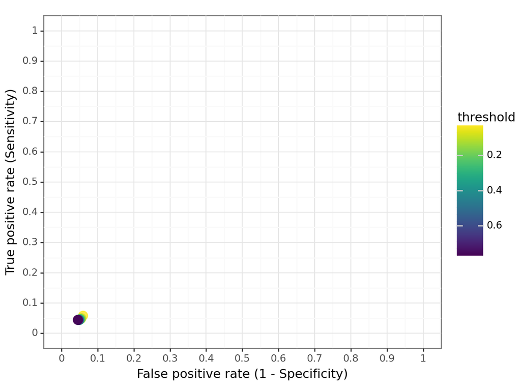

```
<Figure Size: (640 x 480)>
```

```python
(
    ggplot(
        tpr_fpr_for_thresholds,
        aes(x="false_positive_rates", y="true_positive_rates", color="thresholds"),
    )
    + labs(
        x="False positive rate (1 - Specificity)", y="True positive rate (Sensitivity)"
    )
    + geom_point(size=4, alpha=0.8)
    + scale_color_continuous(trans="reverse", name="threshold")
    + scale_x_continuous(limits=(0, 1), breaks=np.arange(0, 1.01, 0.1))
    + scale_y_continuous(limits=(0, 1), breaks=np.arange(0, 1.01, 0.1))
    + theme_bw()
    + theme(legend_position="right")
)
```

Continuous ROC on holdout with best model

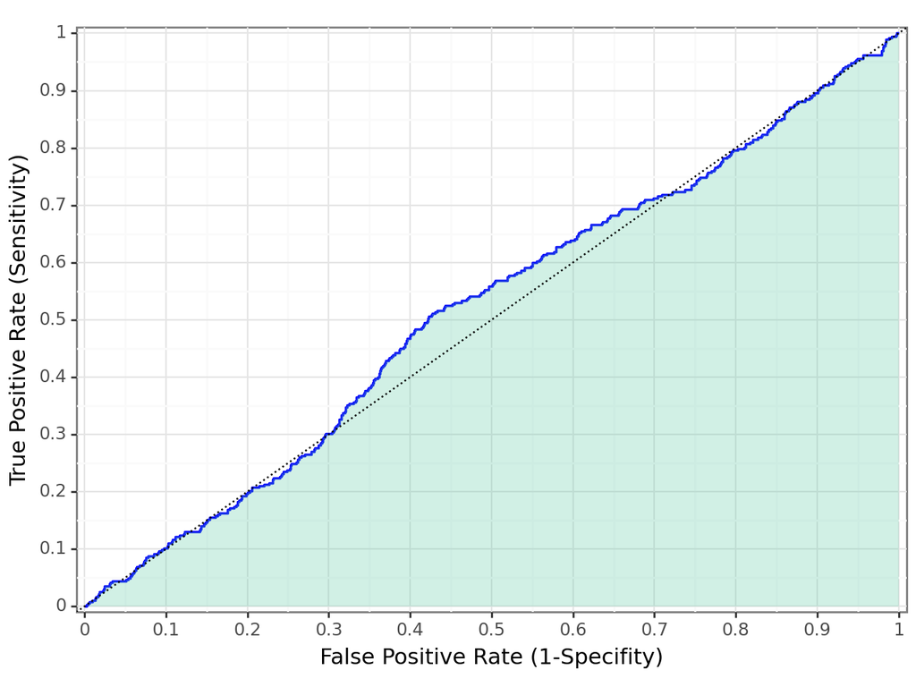

```
<Figure Size: (640 x 480)>
```

```python
create_roc_plot(Y_holdout.ravel(), data_holdout["best_logit_pred_proba"])
```

## 3. We have a loss function

Introduce loss function

Relative cost of of a false negative classification (as compared with a false positive classification)

```python
FP = 1
FN = 10
cost = FN / FP
```

The prevalence, or the proportion of cases in the population (n.cases/(n.controls+n.cases))

```python
prevelance = y_train.sum() / len(y_train)
```

Draw ROC Curve and find optimal threshold with loss function

The optimal cut-off is the threshold that maximizes the distance to the identity (diagonal) line

Iterate through:

1. models
2. Folds

```python
def generate_fold_prediction(model, X, fold, param_index):
    fold_coef = model.coefs_paths_[1][fold, param_index, :]
    intercept = fold_coef[-1]
    betas = fold_coef[:-1]

    # Drop the first column assuming it's the intercept
    X_no_intercept = X.iloc[:, 1:] if X.shape[1] == len(betas) + 1 else X

    return sigmoid_array(np.dot(X_no_intercept, betas) + intercept)
```

```python
best_thresholds_cv = dict()
expected_loss_cv = dict()
fold5_threshold = dict()
fold5_expected_loss = dict()
fold5_all_coords = dict()

for i, model_name in enumerate(logit_models):
    best_thresholds = []
    expected_loss = []

    if model_name != "LASSO":
        Y, X = patsy.dmatrices("high_growth ~" + "+".join(logit_model_vars[i]), data_train)
        X = pd.DataFrame(X)
        c_index = 0
    else:
        X = normalized_logitvars
        c_index = best_lambda_i
    fold = 0
    for train_index, test_index in k.split(X):
        X_fold = X.iloc[test_index, :]
        y_fold = Y.ravel()[test_index]
        pred_fold = generate_fold_prediction(
            logit_models[model_name], X_fold, fold, c_index
        )
        false_pos_rate, true_pos_rate, thresholds = roc_curve(y_fold, pred_fold)
        optimal_threshold = sorted(
            list(
                zip(
                    np.abs(
                        true_pos_rate
                        + (1 - prevelance) / (cost * prevelance) * (1 - false_pos_rate)
                    ),
                    thresholds,
                )
            ),
            key=lambda i: i[0],
            reverse=True,
        )[0][1]
        best_thresholds.append(optimal_threshold)
        threshold_prediction = np.where(pred_fold < optimal_threshold, 0, 1)
        tn, fp, fn, tp = confusion_matrix(
            y_fold, threshold_prediction, labels=[0, 1]
        ).ravel()
        curr_exp_loss = (fp * FP + fn * FN) / len(y_fold)
        expected_loss.append(curr_exp_loss)
        fold = fold + 1

    best_thresholds_cv[model_name] = np.mean(best_thresholds)
    expected_loss_cv[model_name] = np.mean(expected_loss)

    # for fold #5
    fold5_threshold[model_name] = optimal_threshold
    fold5_expected_loss[model_name] = curr_exp_loss

    all_coords = pd.DataFrame(
        {
            "false_pos": false_pos_rate * sum(y_fold == 0),
            "true_pos": true_pos_rate * sum(y_fold == 1),
            "false_neg": sum(y_fold == 1) - true_pos_rate * sum(y_fold == 1),
            "true_neg": sum(y_fold == 0) - false_pos_rate * sum(y_fold == 0),
            "pos": sum(y_fold == 1),
            "neg": sum(y_fold == 0),
            "n": len(y_fold),
            "thresholds": thresholds,
        }
    )

    fold5_all_coords[model_name] = all_coords
```

```python
summary_with_lossfnc = pd.DataFrame(
    best_thresholds_cv.items(), columns=["Model", "Avg of optimal thresholds"]
)
summary_with_lossfnc["Threshold for Fold5"] = fold5_threshold.values()
summary_with_lossfnc["Avg expected loss"] = expected_loss_cv.values()
summary_with_lossfnc["Expected loss for Fold5"] = fold5_expected_loss.values()
```

```python
summary_with_lossfnc
```

|  | Model | Avg of optimal thresholds | Threshold for Fold5 | Avg expected loss | Expected loss for Fold5 |
| --- | --- | --- | --- | --- | --- |
| 0 | M1 | 0.065810 | 0.063822 | 0.241931 | 0.243863 |
| 1 | M2 | 0.071179 | 0.070148 | 0.277266 | 0.281149 |
| 2 | M3 | 0.100969 | 0.103450 | 0.320112 | 0.323358 |
| 3 | M4 | 0.094550 | 0.094654 | 0.350510 | 0.388506 |
| 4 | M5 | 0.088646 | 0.085859 | 0.302638 | 0.311441 |
| 5 | LASSO | 0.086700 | 0.108006 | 0.178616 | 0.170551 |

Create loss plot based on Fold5 in CV

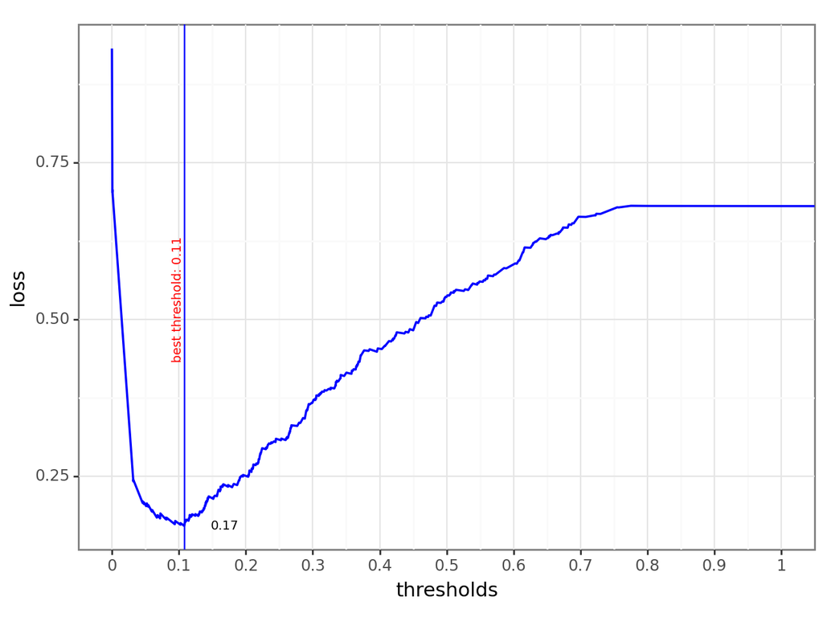

```
<Figure Size: (640 x 480)>
```

```python
model_to_plot = "LASSO"  # select model to plot
create_loss_plot(
    fold5_all_coords[model_to_plot],
    fold5_threshold[model_to_plot],
    fold5_expected_loss[model_to_plot],
)
```

Create roc plot plot based on Fold5 in CV

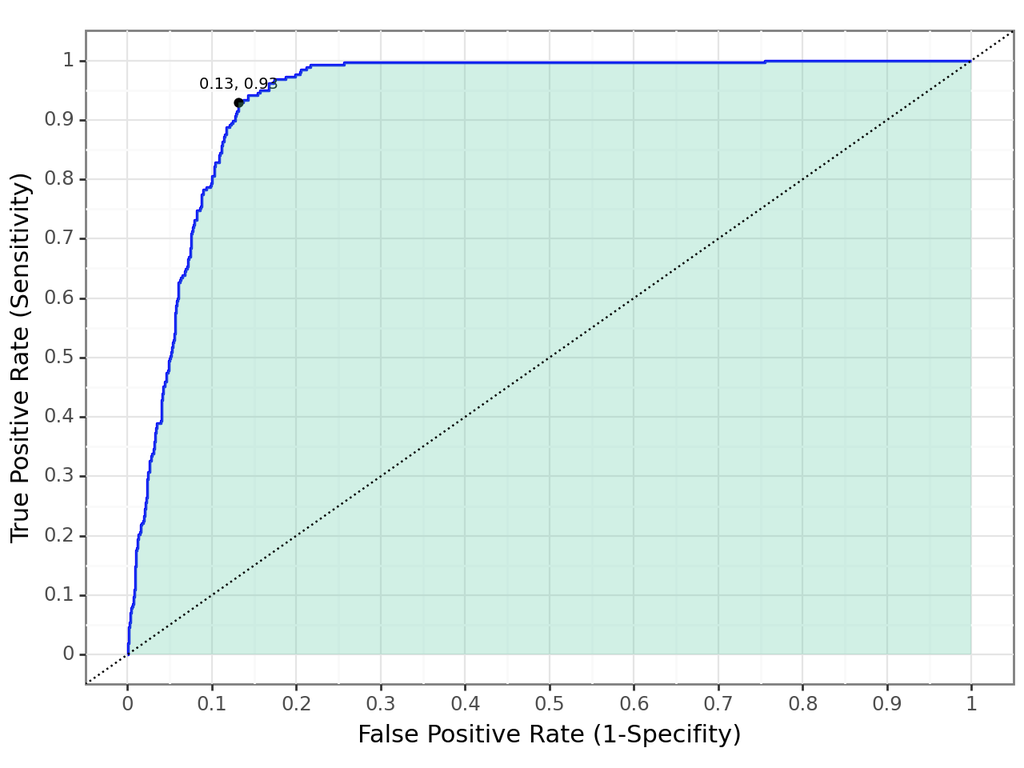

```
<Figure Size: (640 x 480)>
```

```python
create_roc_plot_with_optimal(
    fold5_all_coords[model_to_plot], fold5_threshold[model_to_plot]
)
```

##### Let's see our chosen model, LASSO's holdout expected loss

```python
best_logit_optimal_treshold = best_thresholds_cv["LASSO"]

# Get expected loss on holdout
holdout_treshold = np.where(
    data_holdout["best_logit_pred_proba"] < best_logit_optimal_treshold, 0, 1
)
tn, fp, fn, tp = confusion_matrix(
    Y_holdout.ravel(), holdout_treshold, labels=[0, 1]
).ravel()
expected_loss_holdout = (fp * FP + fn * FN) / len(Y_holdout.ravel())
round(expected_loss_holdout, 3)
```

```
0.779
```

CM on holdout

```python
cm_object3 = confusion_matrix(Y_holdout.ravel(), holdout_treshold, labels=[0, 1])
cm3 = pd.DataFrame(
    cm_object3,
    index=["Actul no high_growth", "Actual high_growth"],
    columns=["Predicted no high_growth", "Predicted high_growth"],
)
cm3
```

|  | Predicted no high_growth | Predicted high_growth |
| --- | --- | --- |
| Actul no high_growth | 4125 | 242 |
| Actual high_growth | 344 | 18 |

# PREDICTION WITH RANDOM FOREST

Again split the data into train and holdout

```python
y_train, rfvars_train = patsy.dmatrices("high_growth~" + "+".join(rfvars), data_train)
y_holdout, rfvars_holdout = patsy.dmatrices("high_growth~" + "+".join(rfvars), data_holdout1)
```

## Probability forest

Split by gini, ratio of 1's in each tree, average over trees

```python
grid = {
    "max_features": [5, 6, 7],
    "criterion": ["gini"],
    "min_samples_split": [11, 16],
}
```

5 fold cross validation

```python
prob_forest = RandomForestClassifier(random_state=42, n_estimators=500, oob_score=True, n_jobs=-1)
prob_forest_grid = GridSearchCV(
    prob_forest,
    grid,
    cv=k,
    refit="roc_auc",
    scoring=["roc_auc", "neg_brier_score"],
)
```

```python
prob_forest_fit = prob_forest_grid.fit(rfvars_train, y_train)
```

Create CV summary table

```python
prob_forest_cv_results = pd.DataFrame(
    {
        "max_features": prob_forest_fit.cv_results_["param_max_features"],
        "min_samples_split": prob_forest_fit.cv_results_["param_min_samples_split"],
        "cv_auc": prob_forest_fit.cv_results_["mean_test_roc_auc"],
        "cv_rmse": np.sqrt(
            prob_forest_fit.cv_results_["mean_test_neg_brier_score"] * -1
        ),
    }
)

prob_forest_cv_results
```

|  | max_features | min_samples_split | cv_auc | cv_rmse |
| --- | --- | --- | --- | --- |
| 0 | 5 | 11 | 0.956848 | 0.197430 |
| 1 | 5 | 16 | 0.956770 | 0.197747 |
| 2 | 6 | 11 | 0.956393 | 0.196892 |
| 3 | 6 | 16 | 0.956795 | 0.196758 |
| 4 | 7 | 11 | 0.956143 | 0.196564 |
| 5 | 7 | 16 | 0.956400 | 0.196605 |

Obtain optimal parameter values

```python
best_mtry = prob_forest_fit.best_params_["max_features"]
best_min_node_size = prob_forest_fit.best_params_["min_samples_split"]
prob_forest_fit.best_params_
```

```
{'criterion': 'gini', 'max_features': 5, 'min_samples_split': 11}
```

Get average (ie over the folds) RMSE and AUC

```python
prob_forest_best_results = prob_forest_cv_results[
    (prob_forest_cv_results.max_features == best_mtry)
    & (prob_forest_cv_results.min_samples_split == best_min_node_size)
]
prob_forest_best_results_index = prob_forest_best_results.index.values[0]
```

```python
summary.loc["RF", "Number of Coefficients"] = "n.a."
summary.loc["RF", "CV RMSE"] = prob_forest_best_results["cv_rmse"].values[0]
summary.loc["RF", "CV AUC"] = prob_forest_best_results["cv_auc"].values[0]
summary
```

|  | Number of Coefficients | CV RMSE | CV AUC |
| --- | --- | --- | --- |
| M1 | 12.0 | 0.231993 | 0.888009 |
| M2 | 19.0 | 0.229760 | 0.881170 |
| M3 | 36.0 | 0.238005 | 0.867201 |
| M4 | 80.0 | 0.240971 | 0.853582 |
| M5 | 154.0 | 0.236864 | 0.883829 |
| LASSO | 87.0 | 0.219100 | 0.939473 |
| RF | n.a. | 0.197430 | 0.956848 |

Extract fold level RMSE and AUC

```python
CV_RMSE_folds["RF"] = np.sqrt(
    pd.DataFrame(prob_forest_fit.cv_results_)
    .filter(like="_test_neg_brier_score")
    .loc[lambda x: x["rank_test_neg_brier_score"] == 1]
    .filter(like="split")
    .values[0]
    * -1
)
CV_AUC_folds["RF"] = (
    pd.DataFrame(prob_forest_fit.cv_results_)
    .filter(like="_test_roc_auc")
    .loc[lambda x: x["rank_test_roc_auc"] == 1]
    .filter(like="split")
    .values[0]
)
```

Take a look at foldwise RMSE and AUC

```python
pd.DataFrame(CV_RMSE_folds)
```

|  | M1 | M2 | M3 | M4 | M5 | LASSO | RF |
| --- | --- | --- | --- | --- | --- | --- | --- |
| 0 | 0.238117 | 0.235665 | 0.236889 | 0.239261 | 0.235919 | 0.217049 | 0.199821 |
| 1 | 0.226850 | 0.224438 | 0.249272 | 0.250465 | 0.247150 | 0.227439 | 0.198400 |
| 2 | 0.236085 | 0.233759 | 0.233632 | 0.234442 | 0.232608 | 0.212571 | 0.196673 |
| 3 | 0.229756 | 0.227308 | 0.238463 | 0.244040 | 0.239414 | 0.223347 | 0.197135 |
| 4 | 0.229159 | 0.227634 | 0.231772 | 0.236648 | 0.229231 | 0.215095 | 0.190668 |

```python
pd.DataFrame(CV_AUC_folds)
```

|  | M1 | M2 | M3 | M4 | M5 | LASSO | RF |
| --- | --- | --- | --- | --- | --- | --- | --- |
| 0 | 0.889923 | 0.875694 | 0.880212 | 0.878067 | 0.896770 | 0.941568 | 0.956502 |
| 1 | 0.887128 | 0.886588 | 0.847575 | 0.847016 | 0.865072 | 0.938076 | 0.958238 |
| 2 | 0.887899 | 0.876434 | 0.877617 | 0.884983 | 0.891487 | 0.943525 | 0.954857 |
| 3 | 0.889354 | 0.884787 | 0.870188 | 0.828461 | 0.887210 | 0.935991 | 0.955453 |
| 4 | 0.885740 | 0.882346 | 0.860415 | 0.829381 | 0.878607 | 0.938205 | 0.959189 |

Now use loss function and search for best thresholds and expected loss over folds

```python
FP = 1
FN = 10
cost = FN / FP
prevelance = y_train.sum() / len(y_train)
```

```python
best_thresholds = list()
expected_loss = list()
rfvars_train = pd.DataFrame(rfvars_train)

fold = 0
for train_index, test_index in k.split(rfvars_train):
    X_fold = rfvars_train.iloc[test_index, :]
    y_fold = data_train["high_growth"].iloc[test_index]

    X_fold_train = rfvars_train.iloc[train_index, :]
    y_fold_train = data_train["high_growth"].iloc[train_index]

    prob_forest_best = RandomForestClassifier(
        random_state=42,
        n_estimators=500,
        oob_score=True,
        criterion="gini",
        max_features=best_mtry,
        n_jobs=-1,
        min_samples_split=best_min_node_size,
    )
    prob_forest_best_fold = prob_forest_best.fit(X_fold_train, y_fold_train)
    pred_fold = prob_forest_best_fold.predict_proba(X_fold)[:, 1]

    false_pos_rate, true_pos_rate, threshold = roc_curve(y_fold, pred_fold)
    best_threshold = sorted(
        list(
            zip(
                np.abs(
                    true_pos_rate
                    + (1 - prevelance) / (cost * prevelance) * (1 - false_pos_rate)
                ),
                threshold,
            )
        ),
        key=lambda x: x[0],
        reverse=True,
    )[0][1]
    best_thresholds.append(best_threshold)
    threshold_prediction = np.where(pred_fold < best_threshold, 0, 1)
    tn, fp, fn, tp = confusion_matrix(
        y_fold, threshold_prediction, labels=[0, 1]
    ).ravel()
    curr_exp_loss = (fp * FP + fn * FN) / len(y_fold)
    expected_loss.append(curr_exp_loss)

fold5_threshold_rf = best_threshold
fold5_expected_loss_rf = curr_exp_loss

all_coords_rf = pd.DataFrame(
    {
        "false_pos": false_pos_rate * sum(y_fold == 0),
        "true_pos": true_pos_rate * sum(y_fold == 1),
        "false_neg": sum(y_fold == 1) - true_pos_rate * sum(y_fold == 1),
        "true_neg": sum(y_fold == 0) - false_pos_rate * sum(y_fold == 0),
        "pos": sum(y_fold == 1),
        "neg": sum(y_fold == 0),
        "n": len(y_fold),
        "thresholds": threshold,
    }
)
```

```python
expected_loss_cv["RF"] = np.mean(expected_loss)
best_thresholds_cv["RF"] = np.mean(best_thresholds)
```

```python
rf_summary = pd.DataFrame(
    {
        "CV RMSE": [round(prob_forest_best_results["cv_rmse"].values[0], 3)],
        "CV AUC": [round(prob_forest_best_results["cv_auc"].values[0], 3)],
        "Avg of optimal thresholds": [round(best_thresholds_cv["RF"], 3)],
        "Threshold for Fold5": [round(best_threshold, 3)],
        "Avg expected loss": [round(expected_loss_cv["RF"], 3)],
        "Expected loss for Fold5": [round(curr_exp_loss, 3)],
    }
)

rf_summary
```

|  | CV RMSE | CV AUC | Avg of optimal thresholds | Threshold for Fold5 | Avg expected loss | Expected loss for Fold5 |
| --- | --- | --- | --- | --- | --- | --- |
| 0 | 0.197 | 0.957 | inf | inf | 0.629 | 0.608 |

Create plots based on Fold5 in CV

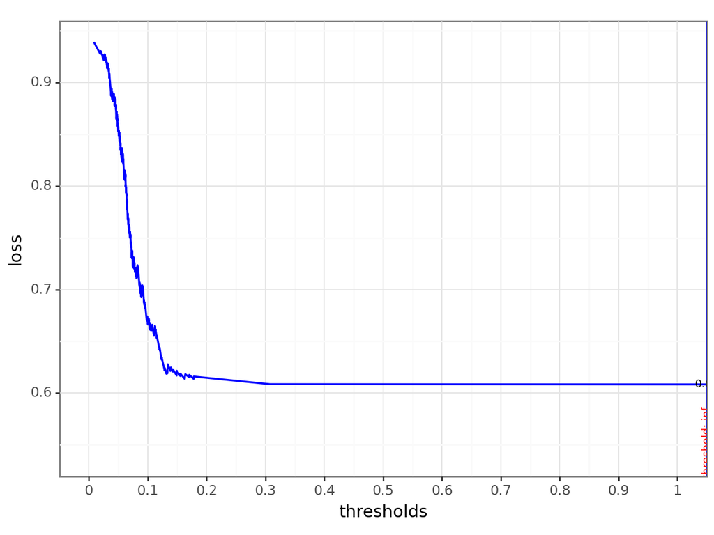

```
<Figure Size: (640 x 480)>
```

```python
create_loss_plot(all_coords_rf, fold5_threshold_rf, fold5_expected_loss_rf)
```

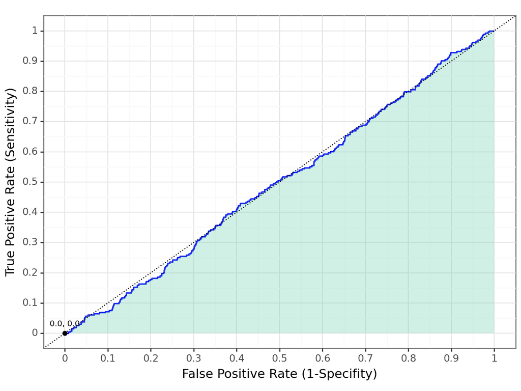

```
<Figure Size: (640 x 480)>
```

```python
create_roc_plot_with_optimal(all_coords_rf, fold5_threshold_rf)
```

Behnam just added the COR plot

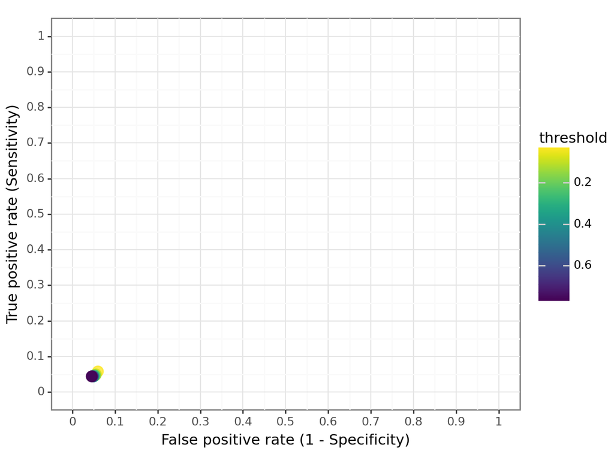

```
<Figure Size: (640 x 480)>
```

```python
(
    ggplot(
        tpr_fpr_for_thresholds,
        aes(x="false_positive_rates", y="true_positive_rates", color="thresholds"),
    )
    + labs(
        x="False positive rate (1 - Specificity)", y="True positive rate (Sensitivity)"
    )
    + geom_point(size=4, alpha=0.8)
    + scale_color_continuous(trans="reverse", name="threshold")
    + scale_x_continuous(limits=(0, 1), breaks=np.arange(0, 1.01, 0.1))
    + scale_y_continuous(limits=(0, 1), breaks=np.arange(0, 1.01, 0.1))
    + theme_bw()
    + theme(legend_position="right")
)
```

Take model to holdout and estimate RMSE, AUC and expected loss

```python
prob_forest_fit_best = prob_forest_fit.best_estimator_
rf_predicted_probabilities_holdout = prob_forest_fit_best.predict_proba(rfvars_holdout)[
    :, 1
]
rmse_rf = np.sqrt(mean_squared_error(y_holdout, rf_predicted_probabilities_holdout))
round(rmse_rf, 3)
```

```
0.201
```

ROC AUC on holdout

```python
auc_rf = roc_auc_score(y_holdout, rf_predicted_probabilities_holdout)
round(auc_rf, 3)
```

```
0.954
```

Get expected loss on holdout

```python
holdout_treshold = np.where(
    rf_predicted_probabilities_holdout < best_thresholds_cv["RF"], 0, 1
)
tn, fp, fn, tp = confusion_matrix(y_holdout, holdout_treshold, labels=[0, 1]).ravel()
expected_loss_holdout = (fp * FP + fn * FN) / len(y_holdout)
round(expected_loss_holdout, 3)
```

```
0.67
```

## Final results

```python
summary["CV treshold"] = best_thresholds_cv
summary["CV expected Loss"] = expected_loss_cv
```

```python
summary
```

|  | Number of Coefficients | CV RMSE | CV AUC | CV treshold | CV expected Loss |
| --- | --- | --- | --- | --- | --- |
| M1 | 12.0 | 0.231993 | 0.888009 | 0.065810 | 0.241931 |
| M2 | 19.0 | 0.229760 | 0.881170 | 0.071179 | 0.277266 |
| M3 | 36.0 | 0.238005 | 0.867201 | 0.100969 | 0.320112 |
| M4 | 80.0 | 0.240971 | 0.853582 | 0.094550 | 0.350510 |
| M5 | 154.0 | 0.236864 | 0.883829 | 0.088646 | 0.302638 |
| LASSO | 87.0 | 0.219100 | 0.939473 | 0.086700 | 0.178616 |
| RF | n.a. | 0.197430 | 0.956848 | inf | 0.629253 |

## An important observation on RF model and solution

CV expected loss shows a high level. It led to curiousity to amend the potential problems with the model. After several solutions, the problem seems to lie in unbalanced sample. One of the proposed solutions in the literature is using another subsample with engineered under-sampling of the catogy that has overrepresentation. With the following fix to the RF model, we see that the expected loss is set to a more rational level.

```python
from sklearn.model_selection import train_test_split
from collections import Counter

# Split off 20% for holdout
_, data_holdout2 = train_test_split(data, train_size=0.8, random_state=42)

# Separate majority and minority classes
majority_class = data[data['high_growth'] == 0]
minority_class = data[data['high_growth'] == 1]

# Undersample the majority class to match the minority
majority_downsampled = majority_class.sample(n=len(minority_class), random_state=42)

# Combine balanced classes
resampled_data = pd.concat([majority_downsampled, minority_class], axis=0).sample(frac=1, random_state=42)  # Shuffle

# Split into features and target again
X_resampled = resampled_data.drop('high_growth', axis=1)
Y_resampled = resampled_data['high_growth']

# Print class distribution
print(f"Original class distribution: {Counter(data['high_growth'])}")
print(f"Resampled class distribution: {Counter(Y_resampled)}")

# Optionally, train/test split of the resampled data
data_train2, _ = train_test_split(resampled_data, train_size=0.8, random_state=42)
```

```
Original class distribution: Counter({0: 25291, 1: 1733})
Resampled class distribution: Counter({1: 1733, 0: 1733})
```

```python
y_train2, rfvars_train2 = patsy.dmatrices("high_growth~" + "+".join(rfvars), data_train2)
y_holdout2, rfvars_holdout2 = patsy.dmatrices("high_growth~" + "+".join(rfvars), data_holdout2)
```

```python
prob_forest_fit2 = prob_forest_grid.fit(rfvars_train2, y_train2)
```

```python
FP = 1
FN = 10
cost = FN / FP
prevelance = y_train2.sum() / len(y_train2)
```

```python
prob_forest_cv_results2 = pd.DataFrame(
    {
        "max_features2": prob_forest_fit2.cv_results_["param_max_features"],
        "min_samples_split2": prob_forest_fit2.cv_results_["param_min_samples_split"],
        "cv_auc2": prob_forest_fit2.cv_results_["mean_test_roc_auc"],
        "cv_rmse2": np.sqrt(
            prob_forest_fit2.cv_results_["mean_test_neg_brier_score"] * -1
        ),
    }
)

prob_forest_cv_results
```

|  | max_features | min_samples_split | cv_auc | cv_rmse |
| --- | --- | --- | --- | --- |
| 0 | 5 | 11 | 0.956848 | 0.197430 |
| 1 | 5 | 16 | 0.956770 | 0.197747 |
| 2 | 6 | 11 | 0.956393 | 0.196892 |
| 3 | 6 | 16 | 0.956795 | 0.196758 |
| 4 | 7 | 11 | 0.956143 | 0.196564 |
| 5 | 7 | 16 | 0.956400 | 0.196605 |

```python
best_mtry2 = prob_forest_fit2.best_params_["max_features"]
best_min_node_size2 = prob_forest_fit2.best_params_["min_samples_split"]
prob_forest_fit2.best_params_
```

```
{'criterion': 'gini', 'max_features': 5, 'min_samples_split': 16}
```

```python
CV_RMSE_folds2=pd.DataFrame()
CV_AUC_folds2=pd.DataFrame()
CV_RMSE_folds2["RF"] = np.sqrt(
    pd.DataFrame(prob_forest_fit2.cv_results_)
    .filter(like="_test_neg_brier_score")
    .loc[lambda x: x["rank_test_neg_brier_score"] == 1]
    .filter(like="split")
    .values[0]
    * -1
)
CV_AUC_folds2["RF"] = (
    pd.DataFrame(prob_forest_fit2.cv_results_)
    .filter(like="_test_roc_auc")
    .loc[lambda x: x["rank_test_roc_auc"] == 1]
    .filter(like="split")
    .values[0]
)
```

```python
pd.DataFrame(CV_RMSE_folds2)
```

|  | RF |
| --- | --- |
| 0 | 0.238486 |
| 1 | 0.242179 |
| 2 | 0.255743 |
| 3 | 0.231173 |
| 4 | 0.242708 |

```python
pd.DataFrame(CV_AUC_folds2)
```

|  | RF |
| --- | --- |
| 0 | 0.967582 |
| 1 | 0.959457 |
| 2 | 0.948948 |
| 3 | 0.965331 |
| 4 | 0.953308 |

```python
# Initialize new lists to store results for RF2 model
best_thresholds2 = list()
expected_loss2 = list()
rfvars_train2 = pd.DataFrame(rfvars_train2)  # Ensure it's the correct variable name

fold2 = 0
for train_index, test_index in k.split(rfvars_train2):  # Using rfvars_train2 for RF2 model
    # Get the test and train data for the fold
    X_fold2 = rfvars_train2.iloc[test_index, :]
    y_fold2 = data_train2["high_growth"].iloc[test_index]  # Using data_train2

    X_fold_train2 = rfvars_train2.iloc[train_index, :]
    y_fold_train2 = data_train2["high_growth"].iloc[train_index]  # Using data_train2

    # We are no longer training the model, using pre-trained RF2 model (prob_forest_fit2)
    prob_forest_best_fold2 = prob_forest_fit2  # Using your pre-trained model (prob_forest_fit2)

    # Make predictions for the fold using the pre-trained model
    pred_fold2 = prob_forest_best_fold2.predict_proba(X_fold2)[:, 1]

    # Calculate the ROC curve and find the best threshold
    false_pos_rate2, true_pos_rate2, threshold2 = roc_curve(y_fold2, pred_fold2)
    best_threshold2 = sorted(
        list(
            zip(
                np.abs(
                    true_pos_rate2
                    + (1 - prevelance) / (cost * prevelance) * (1 - false_pos_rate2)
                ),
                threshold2,
            )
        ),
        key=lambda x: x[0],
        reverse=True,
    )[0][1]

    # Append the best threshold for this fold
    best_thresholds2.append(best_threshold2)

    # Apply the threshold to predictions and compute the confusion matrix
    threshold_prediction2 = np.where(pred_fold2 < best_threshold2, 0, 1)
    tn2, fp2, fn2, tp2 = confusion_matrix(
        y_fold2, threshold_prediction2, labels=[0, 1]
    ).ravel()

    # Calculate expected loss for the fold
    curr_exp_loss2 = (fp2 * FP + fn2 * FN) / len(y_fold2)  # Assuming FP and FN are defined
    expected_loss2.append(curr_exp_loss2)

# Store fold-specific results for the 5th fold of RF2
fold5_threshold_rf2 = best_threshold2
fold5_expected_loss_rf2 = curr_exp_loss2

# Create a DataFrame to store the coordinates for the RF2 model
all_coords_rf2 = pd.DataFrame(
    {
        "false_pos": false_pos_rate2 * sum(y_fold2 == 0),
        "true_pos": true_pos_rate2 * sum(y_fold2 == 1),
        "false_neg": sum(y_fold2 == 1) - true_pos_rate2 * sum(y_fold2 == 1),
        "true_neg": sum(y_fold2 == 0) - false_pos_rate2 * sum(y_fold2 == 0),
        "pos": sum(y_fold2 == 1),
        "neg": sum(y_fold2 == 0),
        "n": len(y_fold2),
        "thresholds": threshold2,
    }
)
```

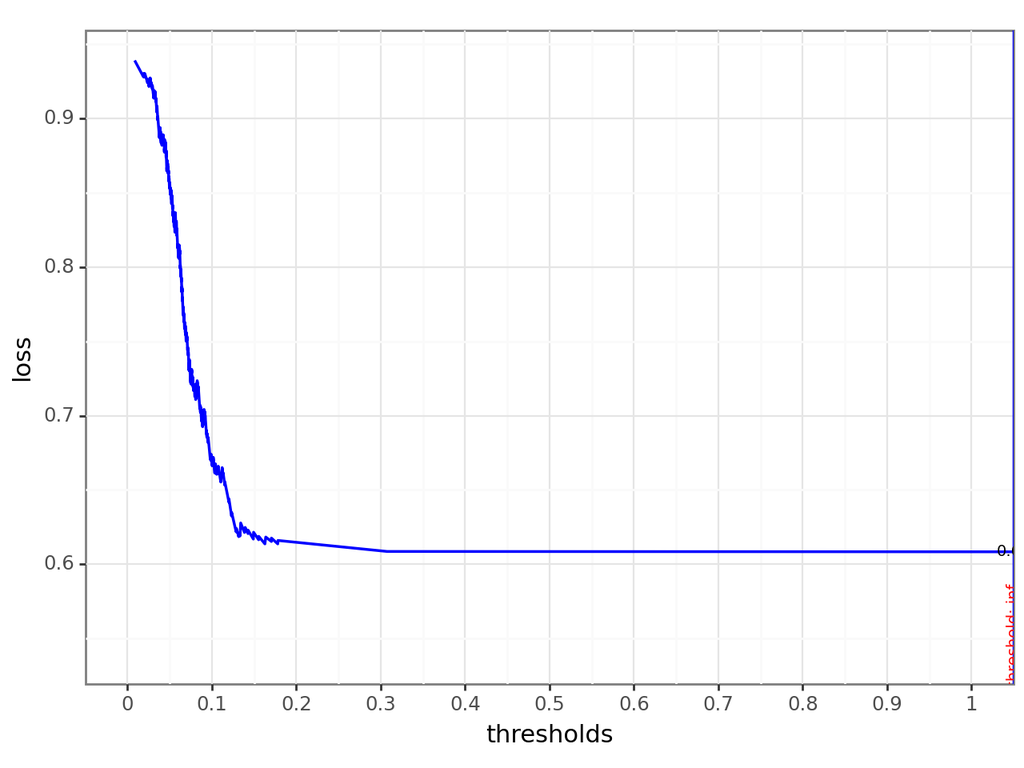

```
<Figure Size: (640 x 480)>
```

```python
create_loss_plot(all_coords_rf, fold5_threshold_rf, fold5_expected_loss_rf)
```

```python
expected_loss_cv["RF2"] = np.mean(expected_loss2)
best_thresholds_cv["RF2"] = np.mean(best_thresholds2)
```

```python
expected_loss_cv["RF2"]
```

```
0.04401925391095066
```

```python
rf_summary = pd.DataFrame(
    {
        "CV RMSE": [round(prob_forest_cv_results2["cv_rmse2"].values[0], 3)],
        "CV AUC": [round(prob_forest_cv_results2["cv_auc2"].values[0], 3)],
        "Avg of optimal thresholds": [round(best_thresholds_cv["RF2"], 3)],
        "Threshold for Fold5": [round(best_threshold, 3)],
        "Avg expected loss": [round(expected_loss_cv["RF2"], 3)],
        "Expected loss for Fold5": [round(curr_exp_loss2, 3)],
    }
)

rf_summary
```

|  | CV RMSE | CV AUC | Avg of optimal thresholds | Threshold for Fold5 | Avg expected loss | Expected loss for Fold5 |
| --- | --- | --- | --- | --- | --- | --- |
| 0 | 0.25 | 0.959 | 0.502 | inf | 0.044 | 0.054 |

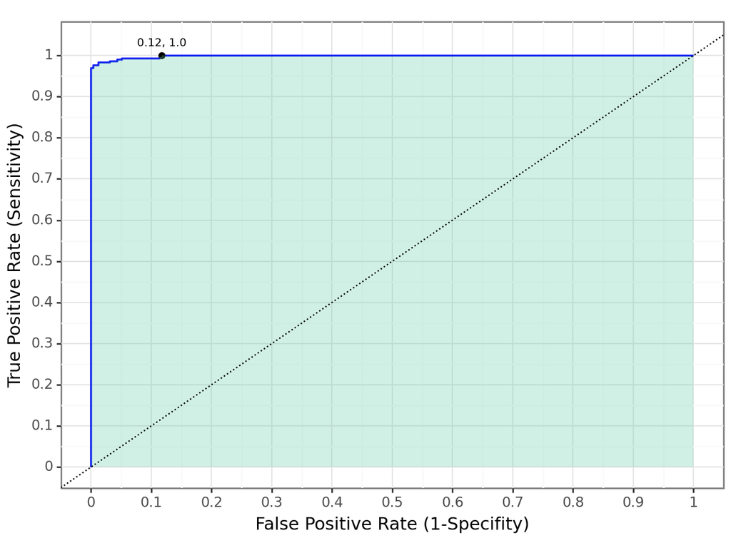

```
<Figure Size: (640 x 480)>
```

```python
create_roc_plot_with_optimal(all_coords_rf2, fold5_threshold_rf2)
```

```python
prob_forest_fit_best2 = prob_forest_fit2.best_estimator_
rf_predicted_probabilities_holdout2 = prob_forest_fit_best2.predict_proba(rfvars_holdout2)[
    :, 1
]
rmse_rf2 = np.sqrt(mean_squared_error(y_holdout2, rf_predicted_probabilities_holdout2))
round(rmse_rf2, 3)
```

```
0.29
```

```python
auc_rf2 = roc_auc_score(y_holdout2, rf_predicted_probabilities_holdout2)
round(auc_rf2, 3)
```

```
0.972
```

```python
holdout_treshold2 = np.where(
    rf_predicted_probabilities_holdout2 < best_thresholds_cv["RF2"], 0, 1
)
tn, fp, fn, tp = confusion_matrix(y_holdout2, holdout_treshold2, labels=[0, 1]).ravel()
expected_loss_holdout2 = (fp * FP + fn * FN) / len(y_holdout2)
round(expected_loss_holdout2, 3)
```

```
0.125
```

```python
prob_forest_cv_results2 = pd.DataFrame(
    {
        "max_features": prob_forest_fit2.cv_results_["param_max_features"],
        "min_samples_split": prob_forest_fit2.cv_results_["param_min_samples_split"],
        "cv_auc": prob_forest_fit2.cv_results_["mean_test_roc_auc"],
        "cv_rmse": np.sqrt(
            prob_forest_fit2.cv_results_["mean_test_neg_brier_score"] * -1
        ),
    }
)

prob_forest_cv_results2
```

|  | max_features | min_samples_split | cv_auc | cv_rmse |
| --- | --- | --- | --- | --- |
| 0 | 5 | 11 | 0.958699 | 0.250199 |
| 1 | 5 | 16 | 0.958925 | 0.251307 |
| 2 | 6 | 11 | 0.958075 | 0.244891 |
| 3 | 6 | 16 | 0.958218 | 0.245132 |
| 4 | 7 | 11 | 0.957500 | 0.242190 |
| 5 | 7 | 16 | 0.957551 | 0.242519 |

```python
prob_forest_best_results2 = prob_forest_cv_results2[
    (prob_forest_cv_results2.max_features == best_mtry2)
    & (prob_forest_cv_results2.min_samples_split == best_min_node_size2)
]
prob_forest_best_results_index2 = prob_forest_best_results2.index.values[0]
```

```python
summary.loc["RF2", "Number of Coefficients"] = "n.a."
summary.loc["RF2", "CV RMSE"] = prob_forest_best_results2["cv_rmse"].values[0]
summary.loc["RF2", "CV AUC"] = prob_forest_best_results2["cv_auc"].values[0]
summary
```

|  | Number of Coefficients | CV RMSE | CV AUC | CV treshold | CV expected Loss |
| --- | --- | --- | --- | --- | --- |
| M1 | 12.0 | 0.231993 | 0.888009 | 0.065810 | 0.241931 |
| M2 | 19.0 | 0.229760 | 0.881170 | 0.071179 | 0.277266 |
| M3 | 36.0 | 0.238005 | 0.867201 | 0.100969 | 0.320112 |
| M4 | 80.0 | 0.240971 | 0.853582 | 0.094550 | 0.350510 |
| M5 | 154.0 | 0.236864 | 0.883829 | 0.088646 | 0.302638 |
| LASSO | 87.0 | 0.219100 | 0.939473 | 0.086700 | 0.178616 |
| RF | n.a. | 0.197430 | 0.956848 | inf | 0.629253 |
| RF2 | n.a. | 0.251307 | 0.958925 | NaN | NaN |

```python
summary["CV treshold"] = best_thresholds_cv
summary["CV expected Loss"] = expected_loss_cv
```

```python
summary
```

|  | Number of Coefficients | CV RMSE | CV AUC | CV treshold | CV expected Loss |
| --- | --- | --- | --- | --- | --- |
| M1 | 12.0 | 0.231993 | 0.888009 | 0.065810 | 0.241931 |
| M2 | 19.0 | 0.229760 | 0.881170 | 0.071179 | 0.277266 |
| M3 | 36.0 | 0.238005 | 0.867201 | 0.100969 | 0.320112 |
| M4 | 80.0 | 0.240971 | 0.853582 | 0.094550 | 0.350510 |
| M5 | 154.0 | 0.236864 | 0.883829 | 0.088646 | 0.302638 |
| LASSO | 87.0 | 0.219100 | 0.939473 | 0.086700 | 0.178616 |
| RF | n.a. | 0.197430 | 0.956848 | inf | 0.629253 |
| RF2 | n.a. | 0.251307 | 0.958925 | 0.502057 | 0.044019 |

# manufacuring firms

```python
#picking the sub-sample only manufacuring firms
manufacturing_data = data[(data["ind2"] >= 10) & (data["ind2"] <= 32)].copy()
```

```python
data_train, data_holdout = train_test_split(manufacturing_data, train_size=0.8, random_state=42)
y_train, rfvars_train = patsy.dmatrices("high_growth~" + "+".join(rfvars), data_train)
y_holdout, rfvars_holdout = patsy.dmatrices("high_growth~" + "+".join(rfvars), data_holdout)
```

```python
FP = 1
FN = 10
cost = FN / FP
prevelance = y_train.sum() / len(y_train)
```

```python
grid = {
    "max_features": [5, 6, 7],
    "criterion": ["gini"],
    "min_samples_split": [11, 16],
}
```

```python
prob_forest = RandomForestClassifier(random_state=42, n_estimators=500, oob_score=True, n_jobs=-1)
prob_forest_grid = GridSearchCV(
    prob_forest,
    grid,
    cv=k,
    refit="roc_auc",
    scoring=["roc_auc", "neg_brier_score"],
)
```

```python
prob_forest_fit_man = prob_forest_grid.fit(rfvars_train, y_train)
```

```python
prob_forest_cv_results3 = pd.DataFrame(
    {
        "max_features": prob_forest_fit_man.cv_results_["param_max_features"],
        "min_samples_split": prob_forest_fit_man.cv_results_["param_min_samples_split"],
        "cv_auc": prob_forest_fit_man.cv_results_["mean_test_roc_auc"],
        "cv_rmse": np.sqrt(
            prob_forest_fit_man.cv_results_["mean_test_neg_brier_score"] * -1
        ),
    }
)

prob_forest_cv_results3
```

|  | max_features | min_samples_split | cv_auc | cv_rmse |
| --- | --- | --- | --- | --- |
| 0 | 5 | 11 | 0.924543 | 0.217994 |
| 1 | 5 | 16 | 0.923377 | 0.218653 |
| 2 | 6 | 11 | 0.925201 | 0.217225 |
| 3 | 6 | 16 | 0.925898 | 0.217267 |
| 4 | 7 | 11 | 0.926042 | 0.216572 |
| 5 | 7 | 16 | 0.924330 | 0.217198 |

```python
best_mtry = prob_forest_fit_man.best_params_["max_features"]
best_min_node_size = prob_forest_fit_man.best_params_["min_samples_split"]
prob_forest_fit_man.best_params_
```

```
{'criterion': 'gini', 'max_features': 7, 'min_samples_split': 11}
```

```python
prob_forest_best_results3 = prob_forest_cv_results3[
    (prob_forest_cv_results3.max_features == best_mtry)
    & (prob_forest_cv_results3.min_samples_split == best_min_node_size)
]
prob_forest_best_results_index3 = prob_forest_best_results3.index.values[0]
```

```python
summary3 = pd.DataFrame()
summary3.loc["RF_man", "CV RMSE"] = prob_forest_best_results3["cv_rmse"].values[0]
summary3.loc["RF_man", "CV AUC"] = prob_forest_best_results3["cv_auc"].values[0]

summary3
```

[output not shown]

```python
CV_RMSE_folds3=pd.DataFrame()
CV_AUC_folds3=pd.DataFrame()
CV_RMSE_folds3["RF_man"] = np.sqrt(
    pd.DataFrame(prob_forest_fit_man.cv_results_)
    .filter(like="_test_neg_brier_score")
    .loc[lambda x: x["rank_test_neg_brier_score"] == 1]
    .filter(like="split")
    .values[0]
    * -1
)
CV_AUC_folds3["RF_man"] = (
    pd.DataFrame(prob_forest_fit_man.cv_results_)
    .filter(like="_test_roc_auc")
    .loc[lambda x: x["rank_test_roc_auc"] == 1]
    .filter(like="split")
    .values[0]
)
```

```python
pd.DataFrame(CV_RMSE_folds3)
```

|  | RF_man |
| --- | --- |
| 0 | 0.221481 |
| 1 | 0.212110 |
| 2 | 0.209050 |
| 3 | 0.227170 |
| 4 | 0.212520 |

```python
pd.DataFrame(CV_AUC_folds3)
```

|  | RF_man |
| --- | --- |
| 0 | 0.927537 |
| 1 | 0.946961 |
| 2 | 0.911595 |
| 3 | 0.922251 |
| 4 | 0.921867 |

```python
best_thresholds = list()
expected_loss = list()
rfvars_train = pd.DataFrame(rfvars_train)

fold = 0
for train_index, test_index in k.split(rfvars_train):
    X_fold = rfvars_train.iloc[test_index, :]
    y_fold = data_train["high_growth"].iloc[test_index]

    X_fold_train = rfvars_train.iloc[train_index, :]
    y_fold_train = data_train["high_growth"].iloc[train_index]

    prob_forest_best = RandomForestClassifier(
        random_state=42,
        n_estimators=500,
        oob_score=True,
        criterion="gini",
        n_jobs=-1,
        max_features=best_mtry,
        min_samples_split=best_min_node_size,
    )
    prob_forest_best_fold = prob_forest_fit_man.fit(X_fold_train, y_fold_train)
    pred_fold = prob_forest_best_fold.predict_proba(X_fold)[:, 1]

    false_pos_rate, true_pos_rate, threshold = roc_curve(y_fold, pred_fold)
    best_threshold = sorted(
        list(
            zip(
                np.abs(
                    true_pos_rate
                    + (1 - prevelance) / (cost * prevelance) * (1 - false_pos_rate)
                ),
                threshold,
            )
        ),
        key=lambda x: x[0],
        reverse=True,
    )[0][1]
    best_thresholds.append(best_threshold)
    threshold_prediction = np.where(pred_fold < best_threshold, 0, 1)
    tn, fp, fn, tp = confusion_matrix(
        y_fold, threshold_prediction, labels=[0, 1]
    ).ravel()
    curr_exp_loss = (fp * FP + fn * FN) / len(y_fold)
    expected_loss.append(curr_exp_loss)

fold5_threshold_rf_man = best_threshold
fold5_expected_loss_rf_man = curr_exp_loss

all_coords_rf_man = pd.DataFrame(
    {
        "false_pos": false_pos_rate * sum(y_fold == 0),
        "true_pos": true_pos_rate * sum(y_fold == 1),
        "false_neg": sum(y_fold == 1) - true_pos_rate * sum(y_fold == 1),
        "true_neg": sum(y_fold == 0) - false_pos_rate * sum(y_fold == 0),
        "pos": sum(y_fold == 1),
        "neg": sum(y_fold == 0),
        "n": len(y_fold),
        "thresholds": threshold,
    }
)
```

```python
rf_man_summary = pd.DataFrame(
    {
        "CV RMSE": [round(prob_forest_best_results3["cv_rmse"].values[0], 3)],
        "CV AUC": [round(prob_forest_best_results3["cv_auc"].values[0], 3)],
        "Avg of optimal thresholds": [round(np.mean(best_thresholds), 3)],
        "Threshold for Fold5": [round(best_threshold, 3)],
        "Avg expected loss": [round(np.mean(expected_loss), 3)],
        "Expected loss for Fold5": [round(curr_exp_loss, 3)],
    }
)

rf_man_summary
```

|  | CV RMSE | CV AUC | Avg of optimal thresholds | Threshold for Fold5 | Avg expected loss | Expected loss for Fold5 |
| --- | --- | --- | --- | --- | --- | --- |
| 0 | 0.217 | 0.926 | 0.115 | 0.143 | 0.49 | 0.547 |

```python
prob_forest_fit_best = prob_forest_fit_man.best_estimator_
rf_predicted_probabilities_holdout = prob_forest_fit_best.predict_proba(rfvars_holdout)[
    :, 1
]
rmse_rf = np.sqrt(mean_squared_error(y_holdout, rf_predicted_probabilities_holdout))
round(rmse_rf, 3)
```

```
0.224
```

```python
auc_rf_man = roc_auc_score(y_holdout, rf_predicted_probabilities_holdout)
round(auc_rf_man, 3)
```

```
0.879
```

```python
holdout_treshold = np.where(
    rf_predicted_probabilities_holdout < best_thresholds_cv["RF"], 0, 1
)
tn, fp, fn, tp = confusion_matrix(y_holdout, holdout_treshold, labels=[0, 1]).ravel()
expected_loss_holdout = (fp * FP + fn * FN) / len(y_holdout)
round(expected_loss_holdout, 3)
```

```
0.62
```

```python
summary3["CV treshold"] = best_thresholds_cv
summary3["CV expected Loss"] = expected_loss_cv
```

```python
summary3
```

[output not shown]

# services

```python
#picking the sub-sample only service firms
Service_data = data[data["ind2"] > 32].copy()
```

```python
data_train, data_holdout = train_test_split(Service_data, train_size=0.8, random_state=42)
y_train, rfvars_train = patsy.dmatrices("high_growth~" + "+".join(rfvars), data_train)
y_holdout, rfvars_holdout = patsy.dmatrices("high_growth~" + "+".join(rfvars), data_holdout)
```

```python
FP = 1
FN = 10
cost = FN / FP
prevelance = y_train.sum() / len(y_train)
```

```python
grid = {
    "max_features": [5, 6, 7],
    "criterion": ["gini"],
    "min_samples_split": [11, 16],
}
```

```python
prob_forest = RandomForestClassifier(random_state=42, n_estimators=500, oob_score=True, n_jobs=-1)
prob_forest_grid = GridSearchCV(
    prob_forest,
    grid,
    cv=k,
    refit="roc_auc",
    scoring=["roc_auc", "neg_brier_score"],
)
```

```python
prob_forest_fit_ser = prob_forest_grid.fit(rfvars_train, y_train)
```

```python
prob_forest_cv_results4 = pd.DataFrame(
    {
        "max_features": prob_forest_fit_ser.cv_results_["param_max_features"],
        "min_samples_split": prob_forest_fit_ser.cv_results_["param_min_samples_split"],
        "cv_auc": prob_forest_fit_ser.cv_results_["mean_test_roc_auc"],
        "cv_rmse": np.sqrt(
            prob_forest_fit_ser.cv_results_["mean_test_neg_brier_score"] * -1
        ),
    }
)

prob_forest_cv_results4
```

|  | max_features | min_samples_split | cv_auc | cv_rmse |
| --- | --- | --- | --- | --- |
| 0 | 5 | 11 | 0.960257 | 0.194884 |
| 1 | 5 | 16 | 0.960554 | 0.194793 |
| 2 | 6 | 11 | 0.960326 | 0.194052 |
| 3 | 6 | 16 | 0.960417 | 0.194172 |
| 4 | 7 | 11 | 0.960102 | 0.193903 |
| 5 | 7 | 16 | 0.960420 | 0.193775 |

```python
best_mtry = prob_forest_fit_ser.best_params_["max_features"]
best_min_node_size = prob_forest_fit_ser.best_params_["min_samples_split"]
prob_forest_fit_ser.best_params_
```

```
{'criterion': 'gini', 'max_features': 5, 'min_samples_split': 16}
```

```python
prob_forest_best_results4 = prob_forest_cv_results4[
    (prob_forest_cv_results4.max_features == best_mtry)
    & (prob_forest_cv_results4.min_samples_split == best_min_node_size)
]
prob_forest_best_results_index4 = prob_forest_best_results4.index.values[0]
```

```python
summary3 = pd.DataFrame()
summary3.loc["RF_ser", "CV RMSE"] = prob_forest_best_results["cv_rmse"].values[0]
summary3.loc["RF_ser", "CV AUC"] = prob_forest_best_results["cv_auc"].values[0]

summary3
```

|  | CV RMSE | CV AUC |
| --- | --- | --- |
| RF_ser | 0.19743 | 0.956848 |

```python
CV_RMSE_folds4=pd.DataFrame()
CV_AUC_folds4=pd.DataFrame()
CV_RMSE_folds4["RF_ser"] = np.sqrt(
    pd.DataFrame(prob_forest_fit_ser.cv_results_)
    .filter(like="_test_neg_brier_score")
    .loc[lambda x: x["rank_test_neg_brier_score"] == 1]
    .filter(like="split")
    .values[0]
    * -1
)
CV_AUC_folds4["RF_ser"] = (
    pd.DataFrame(prob_forest_fit_ser.cv_results_)
    .filter(like="_test_roc_auc")
    .loc[lambda x: x["rank_test_roc_auc"] == 1]
    .filter(like="split")
    .values[0]
)
```

```python
pd.DataFrame(CV_RMSE_folds4)
```

|  | RF_ser |
| --- | --- |
| 0 | 0.190260 |
| 1 | 0.189455 |
| 2 | 0.189987 |
| 3 | 0.199268 |
| 4 | 0.199622 |

```python
pd.DataFrame(CV_AUC_folds4)
```

|  | RF_ser |
| --- | --- |
| 0 | 0.957866 |
| 1 | 0.965992 |
| 2 | 0.961388 |
| 3 | 0.957259 |
| 4 | 0.960265 |

```python
best_thresholds = list()
expected_loss = list()
rfvars_train = pd.DataFrame(rfvars_train)

fold = 0
for train_index, test_index in k.split(rfvars_train):
    X_fold = rfvars_train.iloc[test_index, :]
    y_fold = data_train["high_growth"].iloc[test_index]

    X_fold_train = rfvars_train.iloc[train_index, :]
    y_fold_train = data_train["high_growth"].iloc[train_index]

    prob_forest_best = RandomForestClassifier(
        random_state=42,
        n_estimators=500,
        oob_score=True,
        criterion="gini",
        max_features=best_mtry,
        min_samples_split=best_min_node_size,
    )
    prob_forest_best_fold = prob_forest_fit_ser.fit(X_fold_train, y_fold_train)
    pred_fold = prob_forest_best_fold.predict_proba(X_fold)[:, 1]

    false_pos_rate, true_pos_rate, threshold = roc_curve(y_fold, pred_fold)
    best_threshold = sorted(
        list(
            zip(
                np.abs(
                    true_pos_rate
                    + (1 - prevelance) / (cost * prevelance) * (1 - false_pos_rate)
                ),
                threshold,
            )
        ),
        key=lambda x: x[0],
        reverse=True,
    )[0][1]
    best_thresholds.append(best_threshold)
    threshold_prediction = np.where(pred_fold < best_threshold, 0, 1)
    tn, fp, fn, tp = confusion_matrix(
        y_fold, threshold_prediction, labels=[0, 1]
    ).ravel()
    curr_exp_loss = (fp * FP + fn * FN) / len(y_fold)
    expected_loss.append(curr_exp_loss)

fold5_threshold_rf_ser = best_threshold
fold5_expected_loss_rf_ser = curr_exp_loss

all_coords_rf_ser = pd.DataFrame(
    {
        "false_pos": false_pos_rate * sum(y_fold == 0),
        "true_pos": true_pos_rate * sum(y_fold == 1),
        "false_neg": sum(y_fold == 1) - true_pos_rate * sum(y_fold == 1),
        "true_neg": sum(y_fold == 0) - false_pos_rate * sum(y_fold == 0),
        "pos": sum(y_fold == 1),
        "neg": sum(y_fold == 0),
        "n": len(y_fold),
        "thresholds": threshold,
    }
)
```

```python
expected_loss_cv["RF_ser"] = np.mean(expected_loss)
best_thresholds_cv["RF_ser"] = np.mean(best_thresholds)
```

```python
rf_ser_summary = pd.DataFrame(
    {
        "CV RMSE": [round(prob_forest_best_results4["cv_rmse"].values[0], 3)],
        "CV AUC": [round(prob_forest_best_results4["cv_auc"].values[0], 3)],
        "Avg of optimal thresholds": [round(np.mean(best_thresholds), 3)],
        "Threshold for Fold5": [round(best_threshold, 3)],
        "Avg expected loss": [round(np.mean(expected_loss), 3)],
        "Expected loss for Fold5": [round(curr_exp_loss, 3)],
    }
)

rf_ser_summary
```

|  | CV RMSE | CV AUC | Avg of optimal thresholds | Threshold for Fold5 | Avg expected loss | Expected loss for Fold5 |
| --- | --- | --- | --- | --- | --- | --- |
| 0 | 0.195 | 0.961 | 0.115 | 0.131 | 0.222 | 0.256 |

```python
prob_forest_fit_best = prob_forest_fit_ser.best_estimator_
rf_predicted_probabilities_holdout = prob_forest_fit_best.predict_proba(rfvars_holdout)[
    :, 1
]
rmse_rf = np.sqrt(mean_squared_error(y_holdout, rf_predicted_probabilities_holdout))
round(rmse_rf, 3)
```

```
0.202
```

```python
auc_rf_ser = roc_auc_score(y_holdout, rf_predicted_probabilities_holdout)
round(auc_rf_man, 3)
```

```
0.879
```

```python
holdout_treshold = np.where(
    rf_predicted_probabilities_holdout < best_thresholds_cv["RF"], 0, 1
)
tn, fp, fn, tp = confusion_matrix(y_holdout, holdout_treshold, labels=[0, 1]).ravel()
expected_loss_holdout = (fp * FP + fn * FN) / len(y_holdout)
round(expected_loss_holdout, 3)
```

```
0.659
```

```python
summary3["CV treshold"] = best_thresholds_cv
summary3["CV expected Loss"] = expected_loss_cv
```

```python
summary3
```

|  | CV RMSE | CV AUC | CV treshold | CV expected Loss |
| --- | --- | --- | --- | --- |
| RF_ser | 0.19743 | 0.956848 | 0.114954 | 0.221829 |